# Aula 10: Estrutura de Repetição - While

# Aula 10: Estrutura de Repetição - While

Nesta aula, vamos explorar a estrutura de repetição `while`, que é usada quando o número de iterações necessárias não é conhecido previamente. Diferente do loop `for`, o loop `while` continua executando enquanto uma condição especificada for verdadeira.

## Diferença entre FOR e WHILE

- **FOR**: É usado quando o número de iterações é conhecido de antemão. Podemos interromper a execução com condições específicas, mas o loop em si é definido para percorrer um vetor ou uma sequência conhecida.
- **WHILE**: É ideal para situações em que o número de iterações não é conhecido a priori. O loop continua executando enquanto uma condição for verdadeira, e só para quando essa condição se tornar falsa.

## Estrutura Básica do WHILE

A condição do loop `while` é verificada antes da execução do bloco de código. Se a condição for verdadeira, o código dentro do bloco é executado. A condição é verificada novamente após a execução do bloco, e o processo continua até que a condição se torne falsa.

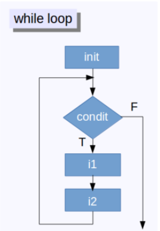

Estrutura WHILE

```r
while (condition) {
  # Execução enquanto a condição for verdadeira
}
```

### Exemplo Básico com `next` e `break`

Vamos criar um exemplo de loop `while` que imprime cada iteração e pula ou interrompe a execução com base em condições específicas.

```r
x <- 1

while (x <= 10) {
  if (x == 5) {
    x <- x + 1
    next  # Pula a iteração quando x é 5
  }
  if (x == 8) {
    break  # Interrompe o loop quando x é 8
  }
  print(x)
  x <- x + 1
}
```

### Exemplo Simples sem `break` ou `next`

Agora, vamos criar um exemplo sem as instruções `break` ou `next`. O loop continuará até que a condição especificada seja falsa.

```r
y <- 2

while (y < 100) {
  print(y)
  y <- y * 2
}
```

Neste exemplo, o loop `while` começa com `y = 2` e continua dobrando o valor de `y` até que `y` seja maior ou igual a 100.

## Exemplo Prático: Sequência de Fibonacci

Vamos continuar com um exemplo usando a sequência de Fibonacci, mas desta vez usaremos o loop `while` para determinar quantos números da sequência são menores que 100.000.

Como não sabemos quantas iterações serão necessárias para alcançar o limite de 100.000, o loop `while` é a escolha ideal.

```r
n_maximo <- 100000
N1 <- 1
N2 <- 1
N3 <- N2 + N1

i <- 3  # Começamos com os primeiros 2 termos conhecidos
while (N3 < n_maximo) {
    cat(N1, N2, N3, "\n")
    N1 <- N2
    N2 <- N3
    N3 <- N2 + N1
    i <- i + 1
}

i  # Quantidade de números da sequência de Fibonacci menores que 100.000
```

## Exemplo Prático: Crescimento Populacional

Vamos criar um exemplo onde calculamos o crescimento populacional de uma cidade ao longo dos anos. O crescimento será calculado com base em uma taxa de crescimento anual até que a população atinja um valor máximo.

```r
populacao_inicial <- 1000
taxa_crescimento <- 0.03  # 3% ao ano
populacao_maxima <- 2000

anos <- 0
populacao <- populacao_inicial

while (populacao < populacao_maxima) {
  populacao <- populacao * (1 + taxa_crescimento)
  anos <- anos + 1
  cat("Ano:", anos, "\tPopulação:", round(populacao), "\n")
}

anos  # Número de anos necessários para a população dobrar
```

### Explicação do Código

- **populacao_inicial**: A população inicial da cidade.
- **taxa_crescimento**: A taxa de crescimento anual (3% ao ano).
- **populacao_maxima**: O limite máximo de população.
- **Loop `while`**: Continua executando até que a população atinja o limite máximo.
- **anos**: Conta o número de anos necessários para que a população dobre de tamanho.

## Exemplo Prático: Aproximação de Pi

```r
pi_aprox <- 0
n <- 1
sinal <- 1
erro <- 1e-6
i <- 0

while (abs(pi_aprox - pi) > erro) {
  pi_aprox <- pi_aprox + sinal * 4/n
  n <- n + 2
  sinal <- -sinal
  i <- i + 1
}

cat("Aproximação de Pi:", pi_aprox, "\n")
cat("Número de termos somados:", i, "\n")
```

### Explicação do Código

- **pi_aprox**: A aproximação atual de Pi.
- **n**: O denominador da fração que é somada/subtraída.
- **sinal**: Alterna entre adicionar e subtrair termos.
- **erro**: A precisão desejada para a aproximação.
- **Loop `while`**: Continua até que a diferença entre `pi_aprox` e o valor real de Pi seja menor que `1e-6`.

## Conclusão

Nesta aula, exploramos a estrutura de repetição `while`, que é usada quando o número de iterações necessárias não é conhecido de antemão. Vimos como usar `while` para resolver problemas em que o loop continua até que uma condição específica seja satisfeita. Esta estrutura é especialmente útil em cálculos iterativos e simulações, onde as condições podem mudar dinamicamente durante a execução do código.